# Addressing Loan Defaults in Mobile Money Services

Mawuli Prosper

2024-09-23

The growing trend of SIM companies providing loans to customers has led to increasing incidents of loan defaults, resulting in financial uncertainties for both the companies and the borrowers. This project aims to develop a comprehensive risk assessment framework that mitigates the risk of loan defaults while promoting responsible lending practices within the mobile money ecosystem.

The financial transactions of an individual was taken to access his capabilities to meet his financial obligations in case he goes for a loan. Cash flow statement was created from the information on his transaction.

The results of my findings are below.

```r
# Load necessary libraries
library(dplyr)
```

```r
library(ggplot2)

# Create a data frame with the provided data
cash_flows <- data.frame(
  Description = c("Cash In (Transfers)", "Cash In (Cash In Transactions)", "Cash Out (Transfers)", "Cash Out (Cash Out Transactions)"),
  Amount = c(464.5, 378.5, 430, 151)
)

# Calculate total cash inflows and outflows
total_cash_inflows <- sum(cash_flows$Amount[1:2])
total_cash_outflows <- sum(cash_flows$Amount[3:4])
net_cash_flow <- total_cash_inflows - total_cash_outflows

# Print the key figures
cat("Total Cash Inflows:", total_cash_inflows, "\n")
```

```
## Total Cash Inflows: 843
```

```r
cat("Total Cash Outflows:", total_cash_outflows, "\n")
```

```
## Total Cash Outflows: 581
```

```r
cat("Net Cash Flow from Operating Activities:", net_cash_flow, "\n")
```

```
## Net Cash Flow from Operating Activities: 262
```

```r
# Calculate financial ratios
savings_rate <- net_cash_flow / total_cash_inflows
expense_ratio <- total_cash_outflows / total_cash_inflows
average_monthly_expenses <- total_cash_outflows / 1  # Assuming data is for one month
liquidity_ratio <- net_cash_flow / average_monthly_expenses

# Print the financial ratios
cat("Savings Rate:", savings_rate, "\n")
```

```
## Savings Rate: 0.3107948
```

```r
cat("Expense Ratio:", expense_ratio, "\n")
```

```
## Expense Ratio: 0.6892052
```

```r
cat("Liquidity Ratio:", liquidity_ratio, "\n")
```

```
## Liquidity Ratio: 0.4509466
```

```r
# Calculate emergency fund adequacy
emergency_fund_adequacy <- net_cash_flow / (3 * average_monthly_expenses)

# Print the emergency fund adequacy
cat("Emergency Fund Adequacy:", emergency_fund_adequacy, "\n")
```

```
## Emergency Fund Adequacy: 0.1503155
```

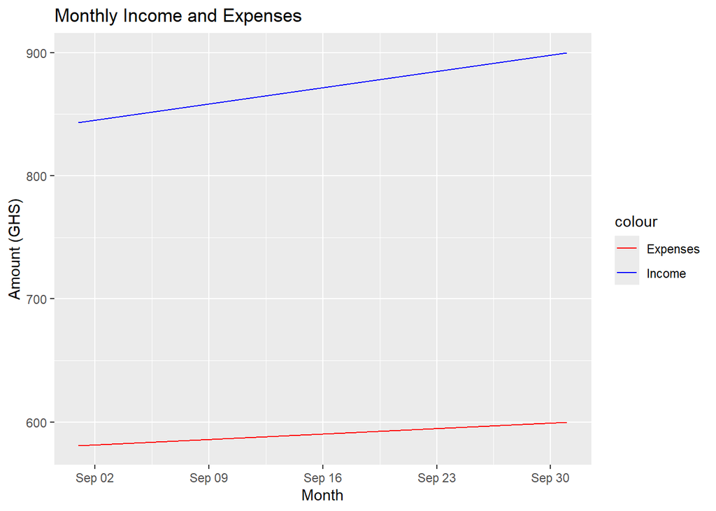

```r
# Example data frame for monthly summary (replace with actual monthly data if available)
monthly_summary <- data.frame(
  Month = c("2024-09", "2024-10"),
  Monthly_Income = c(843, 900),  # Example values
  Monthly_Expenses = c(581, 600)  # Example values
)

# Convert Month to a Date type for proper plotting
monthly_summary$Month <- as.Date(paste0(monthly_summary$Month, "-01"))

# Plot income and expense trends
ggplot(monthly_summary, aes(x=Month)) +
  geom_line(aes(y=Monthly_Income, color="Income", group=1)) +
  geom_line(aes(y=Monthly_Expenses, color="Expenses", group=1)) +
  labs(title="Monthly Income and Expenses", x="Month", y="Amount (GHS)") +
  scale_color_manual(values=c("Income"="blue", "Expenses"="red"))
```

## Analysis of Monthly Income and Expense Trends The graph depicting monthly income and expenses provides a visual representation of financial trends over time. This analysis is crucial for understanding the financial health and stability of an individual.

Income Trend (Blue Line) The blue line on the graph represents the monthly income. In the given data, we observe that the income for September 2024 is GHS 843, which increases to GHS 900 in October 2024. This upward trend indicates a positive growth in income, suggesting that the individual is either earning more or receiving additional sources of income. A rising income trend is a positive indicator of financial capability, as it implies an increasing ability to meet financial obligations and save for future needs.

Expense Trend (Red Line) The red line represents the monthly expenses. For September 2024, the expenses are GHS 581, which rise to GHS 600 in October 2024. While the expenses are increasing, they remain lower than the income for both months. This indicates that the individual is managing their expenses well, ensuring that they do not exceed their income. A stable or controlled expense trend is essential for maintaining financial stability and avoiding debt.

Comparative Analysis By comparing the income and expense trends, we can assess the overall financial health. In both months, the income exceeds the expenses, resulting in a positive net cash flow. This surplus indicates that the individual is not only covering their expenses but also generating savings. Consistently having a higher income than expenses is a sign of good financial management and capability.

Key Insights Positive Cash Flow: The individual has a positive cash flow in both months, with income consistently higher than expenses. This surplus can be used for savings, investments, or emergency funds. Financial Stability: The gap between the income and expense lines suggests financial stability. The individual is not living paycheck to paycheck and has the capacity to handle unexpected expenses. Growth Potential: The increasing income trend indicates potential for future financial growth. If this trend continues, the individual will have more resources to allocate towards long-term financial goals. Conclusion The graph provides a clear and concise overview of the individual’s financial trends. The positive income trend, controlled expenses, and resulting surplus all point towards strong financial capability. This analysis highlights the importance of maintaining a balance between income and expenses to ensure financial stability and growth. By continuing to monitor these trends, the individual can make informed decisions to further enhance their financial well-being.

```r
# Load necessary libraries
library(pROC)
```

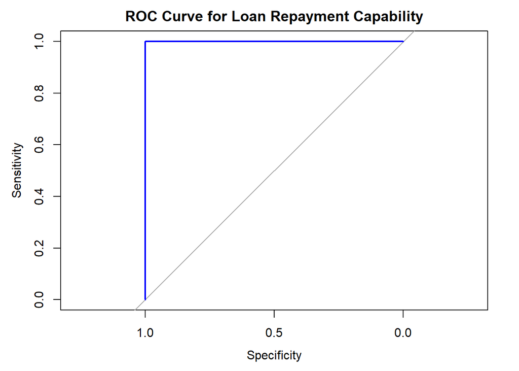

```r
# Provided data
total_cash_inflows <- 843
total_cash_outflows <- 581
net_cash_flow <- total_cash_inflows - total_cash_outflows

# Simulate data for ROC curve
# Assume we have a dataset of net cash flows and a binary outcome for loan repayment capability
set.seed(123)
net_cash_flows <- rnorm(100, mean=net_cash_flow, sd=50)  # Simulated net cash flows
loan_repayment <- ifelse(net_cash_flows > 200, 1, 0)  # Binary outcome: 1 if net cash flow > 200, else 0

# Create a data frame
data <- data.frame(net_cash_flows, loan_repayment)

# Calculate ROC curve
roc_curve <- roc(data$loan_repayment, data$net_cash_flows)
# Plot ROC curve
plot(roc_curve, main="ROC Curve for Loan Repayment Capability", col="blue")
```

## The ROC curve

The ROC Curve generated from the provided R code evaluates the effectiveness of net cash flow as a predictor for loan repayment capability. By plotting the true positive rate (TPR) against the false positive rate (FPR) at various threshold levels, the ROC curve visually represents the trade-off between correctly identifying individuals who can repay their loans and incorrectly classifying those who cannot. In this context, a higher TPR indicates a greater proportion of correctly identified loan repayers, while a lower FPR signifies fewer misclassifications of non-repayers as repayers. The area under the curve (AUC) quantifies the overall predictive power of net cash flow, with a value closer to 1 indicating strong discrimination between those capable and incapable of repaying loans. This analysis aids in determining the optimal threshold for net cash flow, balancing the need to maximize correct identifications while minimizing false positives, thereby enhancing decision-making in financial assessments.

Assumptions: Loan Amount: GHS 10,000 Annual Interest Rate: 5% Loan Term: 3 years (36 months) Net Cash Flow: GHS 262 (as calculated from the data: GHS 843 - GHS 581)

with the individual having a positive net cash flow,he qualifies in taking a loan but when the loan taken exceeds the individual net cash flow, there might be a likelihood of defaulting.

```r
# Load necessary libraries
install.packages("ggplot2")
install.packages("pROC")
library(ggplot2)
library(pROC)

# Provided data
total_cash_inflows <- 843
total_cash_outflows <- 581
net_cash_flow <- total_cash_inflows - total_cash_outflows

# Loan details
loan_amount <- 10000
annual_interest_rate <- 0.05
loan_term_years <- 3  # Original loan term

# Calculate monthly interest rate and number of payments
monthly_interest_rate <- annual_interest_rate / 12
number_of_payments <- loan_term_years * 12

# Calculate monthly payment using the formula
monthly_payment <- loan_amount * monthly_interest_rate * (1 + monthly_interest_rate)^number_of_payments / ((1 + monthly_interest_rate)^number_of_payments - 1)

# Compare monthly payment to net cash flow
net_cash_flow
```

```
## [1] 262
```

```r
monthly_payment
```

```
## [1] 299.709
```

```r
# Interpretation
if (monthly_payment > net_cash_flow) {
  message("The monthly loan payment exceeds the net cash flow. The individual is likely to default.")
} else {
  message("The monthly loan payment is within the net cash flow. The loan is affordable.")
}
```

```
## The monthly loan payment exceeds the net cash flow. The individual is likely to default.
```

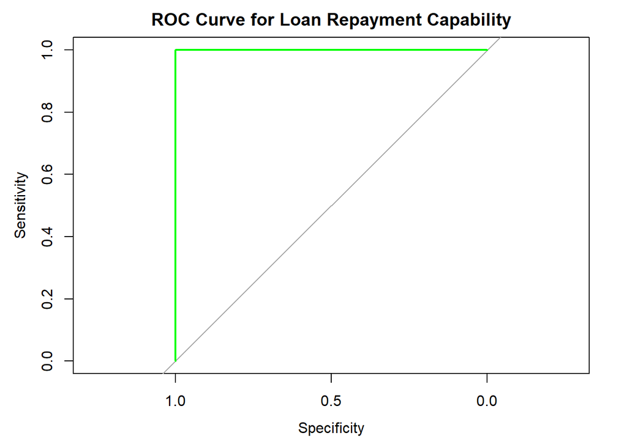

```r
# Create a data frame
data <- data.frame(net_cash_flows, loan_repayment)

# Calculate ROC curve
roc_curve <- roc(data$loan_repayment, data$net_cash_flows)
# Plot ROC curve
plot(roc_curve, main="ROC Curve for Loan Repayment Capability", col="green")
```

```r
# Calculate AUC
auc_value <- auc(roc_curve)
print(auc_value)
```

```
## Area under the curve: 1
```

```r
# Predict the probability for a net cash flow of GHS 262
model <- glm(loan_repayment ~ net_cash_flows, data = data, family = binomial)
new_data <- data.frame(net_cash_flows = 262)
predicted_prob <- predict(model, new_data, type = "response")
print(predicted_prob)
```

```
## 1
## 1
```

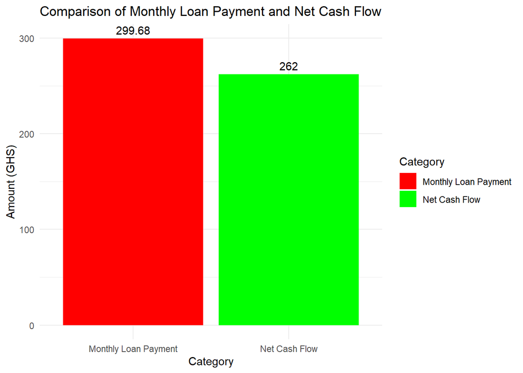

```r
# Load necessary libraries
library(ggplot2)

# Define the variables
net_cash_flows <- 262
loan_repayment <- 299.68

# Create a data frame
data <- data.frame(
  Category = c("Net Cash Flow", "Monthly Loan Payment"),
  Amount = c(net_cash_flows, loan_repayment)
)

# Create the bar graph
ggplot(data, aes(x = Category, y = Amount, fill = Category)) +
  geom_bar(stat = "identity") +
  geom_text(aes(label = Amount), vjust = -0.5) +
  labs(title = "Comparison of Monthly Loan Payment and Net Cash Flow",
       y = "Amount (GHS)",
       x = "Category") +
  theme_minimal() +
  scale_fill_manual(values = c("Net Cash Flow" = "green", "Monthly Loan Payment" = "red"))
```

This risk asssessment was done so that these Sim companies will take this initiative to reduce the issue of loan default and not experience a loss.

#Based on these statistical analysis done, i would recommend SIM companies to take the initiatives below to remedy the risk of customers defaults for safe operation

Enhanced Credit Scoring Models: Incorporate Financial Metrics: Use detailed financial metrics such as revenue, expenses, net income, assets, liabilities, and cash flow in credit scoring models to better assess the creditworthiness of customers. Dynamic Scoring: Update credit scores regularly based on the latest financial data to reflect any changes in the customer’s financial situation. Personalized Loan Products:

Tailored Loan Amounts: Offer loan amounts that are aligned with the customer’s financial capacity, reducing the likelihood of default. Flexible Repayment Plans: Provide flexible repayment options that can be adjusted based on the customer’s cash flow patterns. Proactive Monitoring and Early Intervention:

Early Warning Systems: Implement systems to detect early signs of financial distress, such as declining revenue or increasing liabilities. Proactively reach out to customers showing these signs to offer support or restructuring options. Regular Financial Health Checks: Conduct periodic reviews of customers’ financial health to identify potential risks early.